# Cross-species analysis

Jeremy Miller

September 15, 2021

# Overview

This script performs some statistical analyses and makes some UMAP plots showing glutamatergic neurons in supragranular layers of human MTG and mouse VISp. One purpose is to quantify to what extent the cell type diversity, variation, and specialization of human types extends beyond that of mouse. Note that this script is only considering dissociated cells/nuclei (called “FACS” here) and includes code for generating panels of Figure 1.  
If needed set the working directory: (e.g., `setwd("PATH_TO_DIRECTORY/patchseq_human_L23")`).

### Work space preparation

First, load all the libraries (required for all code documents) and set some options.

```r
# Load all packages
suppressPackageStartupMessages({
  library(genesorteR)
  library(feather)
  library(dplyr)
  library(gplots)
  library(Seurat)
  library(ggplot2)
  library(cowplot)
  library(scrattch.hicat)
  library(scrattch.vis)
  library(future)
  library(ggbeeswarm)
  library(mfishtools) # getBetaScore
  library(pheatmap)
  library(VENcelltypes) # mito_genes and sex_genes
  library(WGCNA)
  library(Matrix)
  library(gridExtra)
})
options(stringsAsFactors=FALSE)
options(future.globals.maxSize = 4000 * 1024^2)
```

Next, load the all the relevant data, which were calculated in previous scripts.

```r
load("input_data_sets.RData")
```

### Plot UMAP of human and mouse IT types here

#### Human

First, select variable features based on beta score (this replaces the default Seurat method and is also independent of the Patch-seq cells).

```r
nGenes     <- 2000
cl         <- setNames(annoMTG$cluster_label,colnames(datMTG))
propExpr   <- get_cl_prop(datMTG,cl)
betaScore  <- getBetaScore(propExpr)
betaOutH   <- data.frame(Gene=rownames(datMTG),BetaScore=betaScore)
betaOutH   <- betaOutH[order(-betaScore),]
varFeatures<- betaOutH$Gene[1:nGenes]
```

Second build the human Seurat object and run the preparations.

```r
spl <- function(a) as.character(lapply(a,function(x) strsplit(x," ")[[1]][4]))
human_metadata <- data.frame(celltype = spl(annoMTG$cluster_label),
                             clusterFrem = spl(annoMTG$frem_layer),
                             layer = annoMTG$layer_label,
                             subclusterFrem = annoMTG$frem_subtype)
rownames(human_metadata) <- colnames(datMTG)
human <- CreateSeuratObject(datMTG, meta.data = human_metadata)
human <- NormalizeData(human, verbose = FALSE)
VariableFeatures(human) <- varFeatures
human <- ScaleData(object = human, verbose = FALSE)
human <- RunPCA(object = human, npcs = 30, verbose = FALSE)
human <- RunUMAP(object = human, reduction = "pca", dims = 1:30, verbose = FALSE)#, umap.method = 'umap-learn')#, metric = 'correlation')
```

```
The default method for RunUMAP has changed from calling Python UMAP via reticulate to the R-native UWOT using the cosine metric
To use Python UMAP via reticulate, set umap.method to 'umap-learn' and metric to 'correlation'
This message will be shown once per session
```

Third, plot the human umap. **Important note: UMAPs may look slightly different with different R configurations due to how the umap functionality is implemented in Seurat. These minor umap differences do not impact manuscript conclusions.**

```r
xl <- range(FetchData(human,"UMAP_1"))
yl <- range(FetchData(human,"UMAP_2"))
cols <- unique(annoMTG$cluster_color)[match(sort(unique(human_metadata$celltype)),unique(human_metadata$celltype))]
f1 <- colnames(human)[annoMTG$frem_subtype!="other"]
pa1 <- DimPlot(object = human, group.by = "subclusterFrem", reduction = "umap", pt.size = 1,
              label=TRUE, label.size = 8, cells=f1) + NoLegend() + xlim(xl) + ylim(yl)
```

```
Using `as.character()` on a quosure is deprecated as of rlang 0.3.0.
Please use `as_label()` or `as_name()` instead.
```

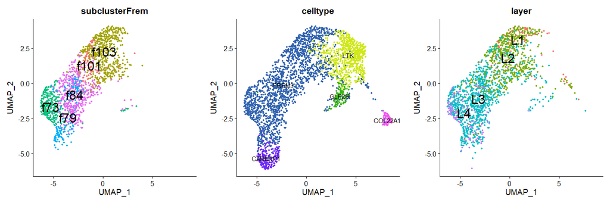

```r
pa2 <- DimPlot(object = human, group.by = "celltype", reduction = "umap", pt.size = 1,
              label=TRUE, cols=cols) + NoLegend() + xlim(xl) + ylim(yl)
f3 <- colnames(human)[annoMTG$cluster_label=="Exc L2-3 LINC00507 FREM3"]
pa3 <- DimPlot(object = human, group.by = "layer",  reduction = "umap", pt.size = 1,
              label=TRUE, label.size = 8, cells=f3) + NoLegend() + xlim(xl) + ylim(yl)
plot_grid(pa1, pa2, pa3, ncol = 3)
```

```r
p_human <- pa2 # For saving coordinates later

## Repeat with labels set to FALSE
xl <- range(FetchData(human,"UMAP_1"))
yl <- range(FetchData(human,"UMAP_2"))
cols <- unique(annoMTG$cluster_color)[match(sort(unique(human_metadata$celltype)),unique(human_metadata$celltype))]
f1 <- colnames(human)[annoMTG$frem_subtype!="other"]
p1 <- DimPlot(object = human, group.by = "subclusterFrem", reduction = "umap", pt.size = 1,
              label=FALSE, label.size = 8, cells=f1) + NoLegend() + xlim(xl) + ylim(yl)
p2 <- DimPlot(object = human, group.by = "celltype", reduction = "umap", pt.size = 1,
              label=FALSE, cols=cols) + NoLegend() + xlim(xl) + ylim(yl)
f3 <- colnames(human)[annoMTG$cluster_label=="Exc L2-3 LINC00507 FREM3"]
p3 <- DimPlot(object = human, group.by = "layer",  reduction = "umap", pt.size = 1,
              label=FALSE, label.size = 8, cells=f3) + NoLegend() + xlim(xl) + ylim(yl)
plot_grid(p1, p2, p3, ncol = 3)
ggsave("UMAP_human.pdf",height=6,width=15)

## Output in a different format
p <- list()
p[[1]] <- list(); p[[1]][[1]] <- pa1
p[[2]] <- list(); p[[2]][[1]] <- pa2
p[[3]] <- list(); p[[3]][[1]] <- pa3
p[[4]] <- list(); p[[4]][[1]] <- p1
p[[5]] <- list(); p[[5]][[1]] <- p2
p[[6]] <- list(); p[[6]][[1]] <- p3
pdf("umap_human_one_per_page.pdf", onefile = TRUE, height=4.5, width=5)
```

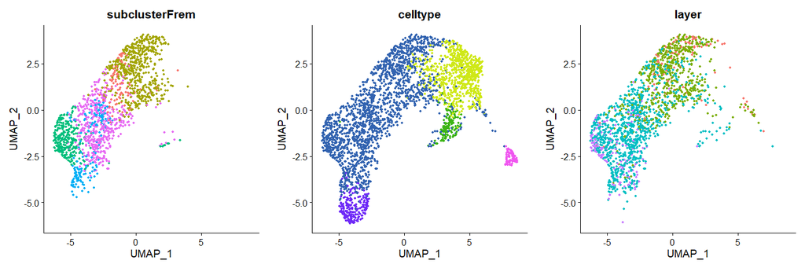

```r
for (i in seq(length(p))) {
  do.call("grid.arrange", p[[i]])
}
dev.off()
```

Use genesorteR to identify genes differentially expressed between FREM3, COL22A1, and CARM1P1 for DEX analysis.

```r
#filter cells
cl3       <- c("Exc L2-3 LINC00507 FREM3", "Exc L3-4 RORB CARM1P1", "Exc L3-5 RORB COL22A1")
kp3       <- is.element(annoMTG$cluster_label,cl3)&
  ((is.element(annoMTG$frem_subtype,c("f73"))&is.element(annoMTG$layer_label,c("L3","L4")))|  #"f79"
     (annoMTG$cluster_label!="Exc L2-3 LINC00507 FREM3"))
propExpr3 <- get_cl_prop(datMTG[,kp3],cl[kp3])


#very roughly filter genes
betaScore3 <- getBetaScore(propExpr3[rowSums(propExpr3[,cl3])>0.3,cl3])
kpGenes3   <- names(sort(-betaScore3))[1:10000]
write(sort(kpGenes3[1:300]),"human_markers_beta300.txt")

#get specificity scores for each cell type
sg = sortGenes(datMTG[kpGenes3,kp3], annoMTG$cluster_label[kp3])
```

```
A Friendly Warning: Some genes were removed because they were zeros in all cells after binarization. You probably don't need to do anything but you might want to look into this. Maybe you forgot to pre-filter the genes? You can also use a different binarization method. Excluded genes are available i…
```

```r
#define a small set of markers
mm3 = getMarkers(sg, quant = 0.7)

#cluster genes and make a heatmap
pp = plotMarkerHeat(sg$inputMat, sg$inputClass, mm3$markers, clusterGenes=TRUE, outs = TRUE)
pdf("dex_heatmap_genesorteR.pdf",height = 15,width=8)
```

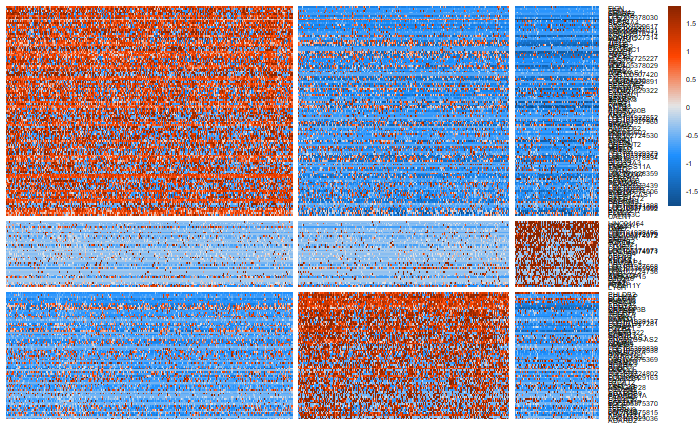

```r
pp$pheat
dev.off()
```

```r
pp = plotMarkerHeat(sg$inputMat, sg$inputClass, kpGenes3[1:300], clusterGenes=TRUE, outs = TRUE)
pdf("dex_heatmap_beta300.pdf",height = 19,width=8)
```

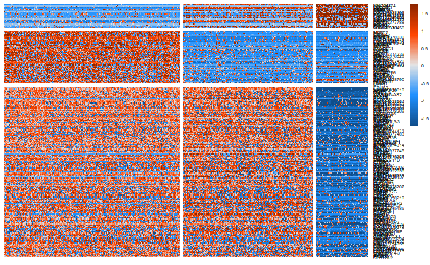

```r
pp$pheat
dev.off()
```

```r
write(sort(mm3$markers),"human_markers_genesorteR.txt")
```

Now use genesorteR to identify genes differentially expressed between deep and superficial L2/3.

```r
#filter cells
cl2       <- c("Exc L2-3 LINC00507 FREM3", "Exc L2-4 LINC00507 GLP2R", "Exc L2 LAMP5 LTK")
kp2       <- is.element(annoMTG$cluster_label,cl2)&
  ((is.element(annoMTG$layer_label,c("L2")))|(annoMTG$cluster_label!="Exc L2-3 LINC00507 FREM3"))
kp        <- kp2|kp3

depth     <- setNames(c("deep","superficial")[kp2+1],colnames(datMTG))
propExpr2 <- get_cl_prop(datMTG[,kp],depth[kp])


#very roughly filter genes
betaScore2 <- getBetaScore(propExpr2)
kpGenes2   <- names(sort(-betaScore2))[1:10000]
write(sort(kpGenes2[1:300]),"human_markers_L23_beta300.txt")

#get specificity scores for each cell type
sg = sortGenes(datMTG[kpGenes2,kp], depth[kp])
```

```
A Friendly Warning: Some genes were removed because they were zeros in all cells after binarization. You probably don't need to do anything but you might want to look into this. Maybe you forgot to pre-filter the genes? You can also use a different binarization method. Excluded genes are available i…
```

```r
#define a small set of markers
mm = getMarkers(sg, quant = 0.7)

#cluster genes and make a heatmap
pp = plotMarkerHeat(sg$inputMat, sg$inputClass, mm$markers, clusterGenes=TRUE, outs = TRUE)
pdf("dex_heatmap_L23_genesorteR.pdf",height = 15,width=8)
```

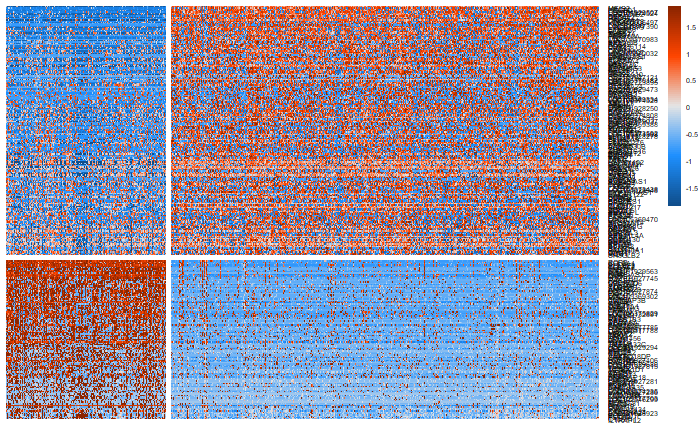

```r
pp$pheat
dev.off()
```

```r
pp = plotMarkerHeat(sg$inputMat, sg$inputClass, kpGenes3[1:300], clusterGenes=TRUE, outs = TRUE)
pdf("dex_heatmap_L23_beta300.pdf",height = 19,width=8)
```

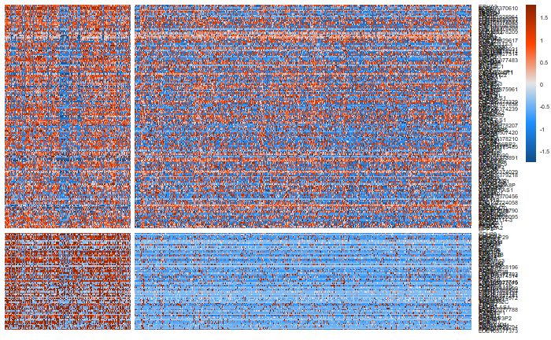

```r
pp$pheat
dev.off()
```

```r
write(sort(mm$markers),"human_markers_L23_genesorteR.txt")
```

```r
features = c("RORB","LAMP5",'CARM1P1',"COL22A1","FREM3","LTK","GLP2R","CUX2")
FeaturePlot(object = human, reduction = "umap", pt.size = 0.5,
                        features = features, ncol=4, slot="counts") +
    ylim(xl) + ylim(yl)

features = c("NEFH",sort(mm3$markers))  # Also including NEFH for inclusion in figure

p<-list()
for (i in 1:length(features)) {
  p[[i]] <- list()
  p[[i]][[1]] <- FeaturePlot(object = human, reduction = "umap", pt.size = 0.5,
                        features = features[i], ncol=1, slot="counts") +
    ylim(xl) + ylim(yl)
}

pdf("genePlots_deepTypes_L3genes.pdf", onefile = TRUE, height=4.5, width=5)
```

```r
for (i in seq(length(p))) {
  do.call("grid.arrange", p[[i]])
}
dev.off()
```

```r
pdf("genePlots_deepTypes_L3genes_Fig4.pdf", onefile = TRUE, height=4.5, width=5)
fig4genes <- which(is.element(features,c("COBLL1","KCNK2","NEFH","NTN4","PHLDB2","QRFPR","SEMA5A","SV2C")))
for (i in fig4genes) {
  do.call("grid.arrange", p[[i]])
}
```

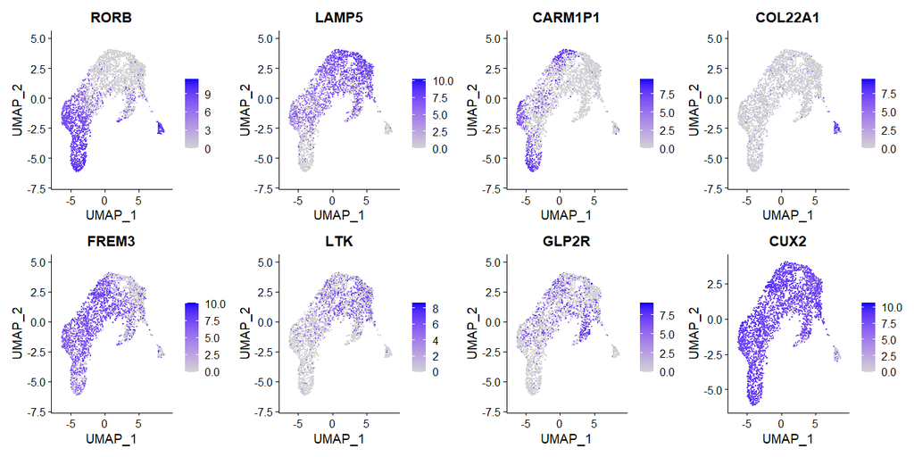

```r
dev.off()
```

#### Mouse VISp

First, select variable features based on beta score (this replaces the default Seurat method and is also independent of the Patch-seq cells).

```r
nGenes     <- 2000
cl         <- setNames(annoVISp$cluster_label,colnames(datVISp))
propExpr   <- get_cl_prop(datVISp,cl)
betaScore  <- getBetaScore(propExpr)
betaOutM   <- data.frame(Gene=rownames(datVISp),BetaScore=betaScore)
betaOutM   <- betaOutM[order(-betaScore),]
varFeatures<- betaOutM$Gene[1:nGenes]
```

Second build the mouse VISp Seurat object and run the preparations.

```r
spl2 <- function(a) as.character(lapply(a,function(x) {a=strsplit(x," ")[[1]]; paste(a[c(1,length(a))],collapse = " ")}))
mouse_metadata <- data.frame(celltype = spl2(annoVISp$cluster_label),
                             clusterFrem = annoVISp$cluster_label)
rownames(mouse_metadata) <- colnames(datVISp)
mouseV <- CreateSeuratObject(datVISp, meta.data = mouse_metadata)
```

```
Feature names cannot have underscores ('_'), replacing with dashes ('-')
```

```r
mouseV <- NormalizeData(mouseV, verbose = FALSE)
#mouseV <- FindVariableFeatures(mouseV, selection.method = "vst", nfeatures = 2000, verbose = FALSE) # 750
VariableFeatures(mouseV) <- varFeatures
mouseV <- ScaleData(object = mouseV, verbose = FALSE)
mouseV <- RunPCA(object = mouseV, npcs = 30, verbose = FALSE)
mouseV <- RunUMAP(object = mouseV, reduction = "pca", dims = 1:30, verbose = FALSE)
```

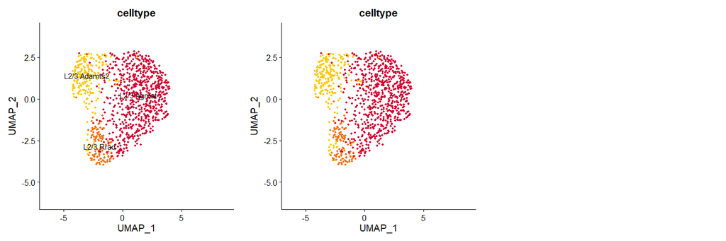

```r
colsM <- unique(annoVISp$cluster_color)[match(sort(unique(mouse_metadata$celltype)),unique(mouse_metadata$celltype))]
p1 <- DimPlot(object = mouseV, group.by = "celltype", reduction = "umap", pt.size = 1,
              label=TRUE, cols=colsM) + NoLegend() + xlim(xl) + ylim(yl)
p2 <- DimPlot(object = mouseV, group.by = "celltype", reduction = "umap", pt.size = 1,
              label=FALSE, cols=colsM) + NoLegend() + xlim(xl) + ylim(yl)
p_mouseV <- p2 # For saving coordinates later
plot_grid(p1, p2, ncol = 3)
```

```r
ggsave("UMAP_mouse_VISp.pdf",height=6,width=15)
```

#### Mouse ALM

First, select variable features based on beta score (this replaces the default Seurat method and is also independent of the Patch-seq cells).

```r
nGenes     <- 2000
cl         <- setNames(annoALM$cluster_label,colnames(datALM))
propExpr   <- get_cl_prop(datALM,cl)
betaScore  <- getBetaScore(propExpr)
betaOutA   <- data.frame(Gene=rownames(datALM),BetaScore=betaScore)
betaOutA   <- betaOutM[order(-betaScore),]
varFeatures<- betaOutA$Gene[1:nGenes]
```

Second build the mouse ALM Seurat object and run the preparations.

```r
spl2 <- function(a) as.character(lapply(a,function(x) {a=strsplit(x," ")[[1]]; paste(a[c(1,length(a))],collapse = " ")}))
mouse_metadata <- data.frame(celltype = spl2(annoALM$cluster_label),
                             clusterFrem = annoALM$cluster_label)
rownames(mouse_metadata) <- colnames(datALM)
mouseA <- CreateSeuratObject(datALM, meta.data = mouse_metadata)
```

```
Feature names cannot have underscores ('_'), replacing with dashes ('-')
```

```r
mouseA <- NormalizeData(mouseA, verbose = FALSE)
#mouseA <- FindVariableFeatures(mouseA, selection.method = "vst", nfeatures = 2000, verbose = FALSE) # 750
VariableFeatures(mouseA) <- varFeatures
mouseA <- ScaleData(object = mouseA, verbose = FALSE)
mouseA <- RunPCA(object = mouseA, npcs = 30, verbose = FALSE)
mouseA <- RunUMAP(object = mouseA, reduction = "pca", dims = 1:30, verbose = FALSE)
```

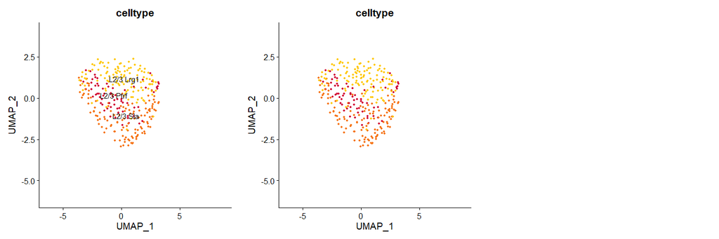

```r
colsM <- unique(annoALM$cluster_color)[match(sort(unique(mouse_metadata$celltype)),unique(mouse_metadata$celltype))]
p1 <- DimPlot(object = mouseA, group.by = "celltype", reduction = "umap", pt.size = 1,
              label=TRUE, cols=colsM) + NoLegend() + xlim(xl) + ylim(yl)
p2 <- DimPlot(object = mouseA, group.by = "celltype", reduction = "umap", pt.size = 1,
              label=FALSE, cols=colsM) + NoLegend() + xlim(xl) + ylim(yl)
p_mouseA <- p2 # For saving coordinates later
plot_grid(p1, p2, ncol = 3)
```

```r
ggsave("UMAP_mouse_ALM.pdf",height=6,width=15)
```

Save UMAP coordinates for human and mouse. These will be used for mapping Patch-seq data in later scripts.

```r
umap_human  <- p_human$data[,c("UMAP_1","UMAP_2")]
umap_mouseV <- p_mouseV$data[,c("UMAP_1","UMAP_2")]
umap_mouseA <- p_mouseA$data[,c("UMAP_1","UMAP_2")]
save(umap_human,umap_mouseV,umap_mouseA,file="umap_coordinates.RData")
```

### Assess cluster heterogeneity in mouse VISp/ALM and human MTG

To assess cluster heterogeneity, we will compare the variance explained from the first PC in real data against the variance epxlained from the first PC in random shufflings of the data. Clusters with high heterogeneity should also have at least one signficant PC relative to the expected PC value from chance. We will downsample to the same number of cells per cluster and use the same number of variable genes calculated the same way in mouse and human for a fair comparison. We are also excluding outlier samples from the PC calculation to insure that the results are not driven by a small number of outlier or low quality cells, and are excluding sex and mitochondrial genes.

First some housekeeping things (functions, common and non-excluded genes).

```r
## Select the genes of common mouse/human genes that are not sex or mitochondrial genes for later
data(mito_genes)
data(sex_genes)
excludeGenes <- sort(unique(c(sex_genes,mito_genes)))
kpGenes <- intersect(rownames(datVISp),rownames(datMTG))
kpGenes <- sort(setdiff(kpGenes,excludeGenes))

## Required functions
findFromGroupsVector <- function(x,y,...) {
 x = as.numeric(x)
 x = cbind(x,x)
 f = findFromGroups(x,y,...)
 return(colMeans(f))
}

# This function calculates the top PCs after removing any outlier cells
# (to account for potential low-quality or misassigned cells)
prcompAfterOutlierRemoval <- function(tnorm.dat,gnUse=1:dim(tnorm.dat)[2],kpCl=1:dim(tnorm.dat)[2],zThresh){
  pcaUse <- prcomp(tnorm.dat[kpCl,gnUse])
  go = TRUE
  # Check for outliers and recalculate PCs until no outliers remain.
  while(go&length(kpCl>10)){
    z1 = pcaUse$x[,1];  z1 = (z1-mean(z1))/sd(z1)
    z2 = pcaUse$x[,2];  z2 = (z2-mean(z2))/sd(z2)
    # Check for outliers
    kpTmpS = pmax(abs(z1),abs(z2))<zThresh
    if (sum(!kpTmpS)==0){
      go = FALSE
    } else {
      kpCl[kpCl][!kpTmpS] = FALSE
      pcaUse <- prcomp(tnorm.dat[kpCl,gnUse])
    }
  }
  return(pcaUse)
}
```

Next, find the actual and permuted PCs in human.

```r
set.seed(1)
nCells  <- 70     # Decreasing from 80 to 70 to match the minimum size of ALM clusters (L2/3 IT ALM Ptrf)
nGenes  <- nCells
rCount  <- 10 # 2
pCount  <- 100
zThresh <- 3
pcMax   <- 10
p1h <- p1hr <- list()
clustsH <- sort(unique(annoMTG$cluster_label))[c(3,2,1,4,5)] # Order superficial to deep
for(cls in clustsH){
  print(cls)
  for (i in 1:rCount){
    if(i==1) {
      p1h[[cls]]  <- NULL
      p1hr[[cls]] <- NULL
    }
    set.seed(i)
    kpCell <- sample(colnames(datMTG)[annoMTG$cluster_label==cls],nCells)
    nbt    <- CreateSeuratObject(datMTG[kpGenes,kpCell])
    nbt    <- FindVariableFeatures(nbt, selection.method = "vst", nfeatures = nGenes, mean.cutoff = c(1,Inf), verbose = FALSE)
    datTmp <- as.matrix(FetchData(nbt,vars = VariableFeatures(nbt), slot="counts"))
    pcaUse <- prcompAfterOutlierRemoval(datTmp,zThresh=zThresh)
    varExp <- ((10000*(pcaUse$sdev)^2 / sum(pcaUse$sdev^2))/100)[1:pcMax]
    p1h[[cls]] <- rbind(p1h[[cls]],varExp)
    for (j in 1:pCount){
      set.seed(i*pCount+j)
      datRand <- t(apply(datTmp,1,function(x) return(x[sample(1:length(x),length(x))])))
      colnames(datRand) <- colnames(datTmp)
        pcaRand <- prcompAfterOutlierRemoval(datRand,zThresh=zThresh)
        varExpR <- ((10000*(pcaRand$sdev)^2 / sum(pcaRand$sdev^2))/100)[1:pcMax]
        p1hr[[cls]] <- rbind(p1hr[[cls]],varExp/varExpR)
    }
  }
}
```

```
[1] "Exc L2 LAMP5 LTK"
[1] "Exc L2-4 LINC00507 GLP2R"
[1] "Exc L2-3 LINC00507 FREM3"
[1] "Exc L3-4 RORB CARM1P1"
[1] "Exc L3-5 RORB COL22A1"
```

Repeat, finding the actual and permuted PCs in mouse VISp.

```r
clustsM <- sort(unique(annoVISp$cluster_label))[c(1,3,2)] # Order superficial to deep
for(cls in clustsM){
  print(cls)
  for (i in 1:rCount){
    if(i==1) {
      p1h[[cls]]  <- NULL
      p1hr[[cls]] <- NULL
    }
    set.seed(i)
    kpCell <- sample(colnames(datVISp)[annoVISp$cluster_label==cls],nCells)
    nbt    <- CreateSeuratObject(datVISp[kpGenes,kpCell])
    nbt    <- FindVariableFeatures(nbt, selection.method = "vst", nfeatures = nGenes, mean.cutoff = c(1,Inf), verbose = FALSE)
    datTmp <- as.matrix(FetchData(nbt,vars = VariableFeatures(nbt), slot="counts"))
    pcaUse <- prcompAfterOutlierRemoval(datTmp,zThresh=zThresh)
    varExp <- ((10000*(pcaUse$sdev)^2 / sum(pcaUse$sdev^2))/100)[1:pcMax]
    p1h[[cls]] <- rbind(p1h[[cls]],varExp)
    for (j in 1:pCount){
      set.seed(i*pCount+j)
      datRand <- t(apply(datTmp,1,function(x) return(x[sample(1:length(x),length(x))])))
      colnames(datRand) <- colnames(datTmp)
        pcaRand <- prcompAfterOutlierRemoval(datRand,zThresh=zThresh)
        varExpR <- ((10000*(pcaRand$sdev)^2 / sum(pcaRand$sdev^2))/100)[1:pcMax]
        p1hr[[cls]] <- rbind(p1hr[[cls]],varExp/varExpR)
    }
  }
}
```

```
[1] "L2/3 IT VISp Adamts2"
[1] "L2/3 IT VISp Rrad"
[1] "L2/3 IT VISp Agmat"
```

Repeat, finding the actual and permuted PCs in mouse ALM.

```r
clustsA <- sort(unique(annoALM$cluster_label))[c(1,3,2)] # No specific order
for(cls in clustsA){
  print(cls)
  for (i in 1:rCount){
    if(i==1) {
      p1h[[cls]]  <- NULL
      p1hr[[cls]] <- NULL
    }
    set.seed(i)
    kpCell <- sample(colnames(datALM)[annoALM$cluster_label==cls],nCells)
    nbt    <- CreateSeuratObject(datALM[kpGenes,kpCell])
    nbt    <- FindVariableFeatures(nbt, selection.method = "vst", nfeatures = nGenes, mean.cutoff = c(1,Inf), verbose = FALSE)
    datTmp <- as.matrix(FetchData(nbt,vars = VariableFeatures(nbt), slot="counts"))
    pcaUse <- prcompAfterOutlierRemoval(datTmp,zThresh=zThresh)
    varExp <- ((10000*(pcaUse$sdev)^2 / sum(pcaUse$sdev^2))/100)[1:pcMax]
    p1h[[cls]] <- rbind(p1h[[cls]],varExp)
    for (j in 1:pCount){
      set.seed(i*pCount+j)
      datRand <- t(apply(datTmp,1,function(x) return(x[sample(1:length(x),length(x))])))
      colnames(datRand) <- colnames(datTmp)
        pcaRand <- prcompAfterOutlierRemoval(datRand,zThresh=zThresh)
        varExpR <- ((10000*(pcaRand$sdev)^2 / sum(pcaRand$sdev^2))/100)[1:pcMax]
        p1hr[[cls]] <- rbind(p1hr[[cls]],varExp/varExpR)
    }
  }
}
```

```
[1] "L2/3 IT ALM Macc1 Lrg1"
[1] "L2/3 IT ALM Sla"
[1] "L2/3 IT ALM Ptrf"
```

Now plot the results, comparing variation across all 11 types.

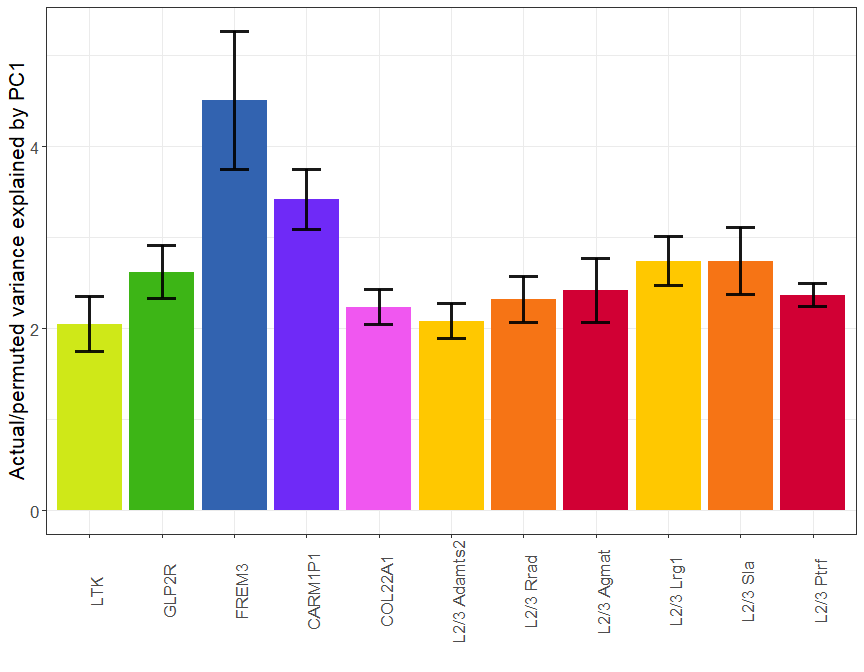

```r
meanDiff <- sdDiff <- NULL
for (cls in names(p1hr)){
  meanDiff <- rbind(meanDiff,colMeans(p1hr[[cls]]))
  sdDiff   <- rbind(sdDiff, apply(p1hr[[cls]],2,sd))
}
rownames(meanDiff) <- rownames(sdDiff) <- names(p1hr)
colnames(meanDiff) <- colnames(sdDiff) <- paste0("PC",1:pcMax)

# Data
data <- data.frame(
  name=factor(c(spl(clustsH),spl2(clustsM),spl2(clustsA)),levels=c(spl(clustsH),spl2(clustsM),spl2(clustsA))),
  value=meanDiff[,1],
  sd=sdDiff[,1]
)

a = setNames(c(annoVISp$cluster_color,annoALM$cluster_color,annoMTG$cluster_color),
             c(annoVISp$cluster_label,annoALM$cluster_label,annoMTG$cluster_label))
data$cols <- as.character(a[rownames(data)])

# line + dot
ggplot(data) +
  geom_bar( aes(x=name, y=value), stat="identity", fill=data$cols, alpha=1)+#0.5) +
  geom_errorbar( aes(x=name, ymin=value-sd, ymax=value+sd), width=0.4, colour="black", alpha=0.9, size=1.3) +
  ylab("Actual/permuted variance explained by PC1") + xlab("") + theme_bw() +
  theme(axis.text.x = element_text(angle = 90), text = element_text(size=16))
```

```r
ggsave("heterogeneity.pdf",height=8,width=6)
```

## Cluster discreteness (based on number of pairwise DEX genes)

```r
de.param   <- de_param(low.th = 1, padj.th = 0.01, lfc.th = 1,    # Recommended parameters for SMART-seq data
                       q1.th = 0.5, q.diff.th = 0.7, de.score.th = 150)
humanCount <- mouseCountV <- mouseCountA <- 0
numIters   <- 10

for (n in 1:numIters){
  ## Human
  cl <- setNames(make.names(annoMTG$cluster_label),annoMTG$sample_id)
  nm <- sort(unique(cl))
  kpSamp <- subsampleCells(cl,subSamp=nCells,seed=n)
  human_de <- de_score(datMTG[kpGenes, kpSamp], cl[kpSamp], de.param)
  human_count <- matrix(0, ncol = length(nm), nrow = length(nm))
  rownames(human_count) <- colnames(human_count) <- nm
  for (i in 1:(length(nm)-1)) for (j in (i+1):length(nm)){
    human_count[i,j] = human_de$de.genes[[paste(nm[i],nm[j],sep="_")]]$up.num
    human_count[j,i] = human_de$de.genes[[paste(nm[i],nm[j],sep="_")]]$down.num
  }
  humanCount = human_count + humanCount

  ## Mouse VISp
  cl <- setNames(make.names(annoVISp$cluster_label),annoVISp$sample_id)
  nm <- sort(unique(cl))
  kpSamp <- subsampleCells(cl,subSamp=nCells,seed=n)
  mouse_de <- de_score(datVISp[kpGenes, kpSamp], cl[kpSamp], de.param)
  mouse_count <- matrix(0, ncol = length(nm), nrow = length(nm))
  rownames(mouse_count) <- colnames(mouse_count) <- nm
  for (i in 1:(length(nm)-1)) for (j in (i+1):length(nm)){
    mouse_count[i,j] = mouse_de$de.genes[[paste(nm[i],nm[j],sep="_")]]$up.num
    mouse_count[j,i] = mouse_de$de.genes[[paste(nm[i],nm[j],sep="_")]]$down.num
  }
  mouseCountV = mouse_count + mouseCountV

  ## Mouse ALM
  cl <- setNames(make.names(annoALM$cluster_label),annoALM$sample_id)
  nm <- sort(unique(cl))
  kpSamp <- subsampleCells(cl,subSamp=nCells,seed=n)
  mouse_de <- de_score(datALM[kpGenes, kpSamp], cl[kpSamp], de.param)
  mouse_count <- matrix(0, ncol = length(nm), nrow = length(nm))
  rownames(mouse_count) <- colnames(mouse_count) <- nm
  for (i in 1:(length(nm)-1)) for (j in (i+1):length(nm)){
    mouse_count[i,j] = mouse_de$de.genes[[paste(nm[i],nm[j],sep="_")]]$up.num
    mouse_count[j,i] = mouse_de$de.genes[[paste(nm[i],nm[j],sep="_")]]$down.num
  }
  mouseCountA = mouse_count + mouseCountA
}
mouseCountV = (mouseCountV+t(mouseCountV))/numIters
mouseCountA = (mouseCountA+t(mouseCountA))/numIters
humanCount  = (humanCount+t(humanCount))/numIters
print(paste("Human     :",sum(humanCount[1:3,1:3])/6))
```

```
[1] "Human     : 25.0333333333333"
```

```r
print(paste("Mouse VISp:",sum(mouseCountV[1:3,1:3])/6))
```

```
[1] "Mouse VISp: 32.5"
```

```r
print(paste("Mouse ALM :",sum(mouseCountA[1:3,1:3])/6))
```

```
[1] "Mouse ALM : 31.9333333333333"
```

Comparable DEX genes in matched L2/3 types in mouse and human (maybe fewer in human) after matching for number of cells. Plot these results.

```r
out <- t(cbind(humanCount[1:3,],mouseCountV,mouseCountA))
colnames(out) <- 1:3
out[out==0]=NA
out <- as.data.frame(out)
out$name <- rownames(out) <- data$name

barplot(apply(out[,1:3],1,mean,na.rm=TRUE),las=2,col=data$cols, ylab="# DEX genes wrt matched human/mouse types",border="white")

pdf("discreteness.pdf",height=8,width=4)
```

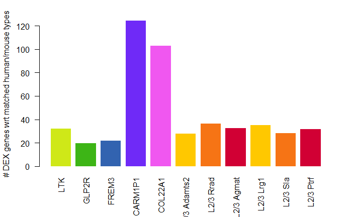

```r
barplot(apply(out[,1:3],1,mean,na.rm=TRUE),las=2,col=data$cols, ylab="# DEX genes wrt matched human/mouse types",border="white")
dev.off()
```

## Expression of mFISH markers in FACS

Finally, let’s plot the expected cell type specificity of marker genes that are used in mFISH experiments to assess laminar localization of cell types in situ. Note that an older interacitve version of the scripts were used to make the version of the plot in Extended Data Figure 3d, but that the overall pattern (and thus conclusions based on this plot) are entirely unchanged.

```
`group_by_()` was deprecated in dplyr 0.7.0.
Please use `group_by()` instead.
See vignette('programming') for more help`arrange_()` was deprecated in dplyr 0.7.0.
Please use `arrange()` instead.
See vignette('programming') for more help
```

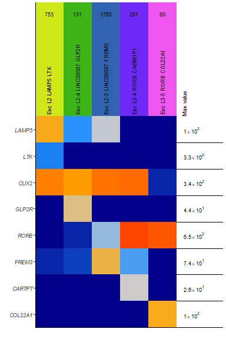

```r
mark    <- c("LAMP5","LTK","CUX2","GLP2R","RORB","FREM3","CARTPT","COL22A1")
data.df <- cbind(sample_name = colnames(datMTG), as.data.frame(2^t(datMTG[mark,])-1))
anno    <- data.frame(sample_name=as.character(annoMTG$sample_id),
                      cluster_label=as.character(annoMTG$cluster_label),
                      cluster_color=as.character(annoMTG$cluster_color))
anno$cluster_id <- as.numeric(factor(anno$cluster_label,levels=clustsH))
scrattch.vis::group_heatmap_plot(data.df, anno, genes=mark, grouping ="cluster", stat="median",
                                 log_scale = TRUE, max_width = 30, label_height = 35)
```